# Assignment 7

Feiyu Zheng (fz114)

2022/3/22

# Problem 1

## 1. From the worldometer webpage [https://www.worldometers.info/coronavirus/](https://www.worldmeters.info/coronavirus/), extract the country-wise COVID data. Treat it as a static HTML webpage. Create a tibble showing the country-wise data for the following four variables only: total cases, new cases, total deaths and new deaths. Clean the data to make them amenable to analysis.

### Download the table from worldometer webpage

```r
url <- "https://www.worldometers.info/coronavirus"
country_covid_table <- url %>%
  read_html() %>%
  html_nodes("table") %>%
  html_table(fill = TRUE) %>%
  .[[1]]
country_covid_table
```

```
## # A tibble: 243 x 22
##      `#` `Country,Other` TotalCases  NewCases   TotalDeaths NewDeaths
##    <int> <chr>           <chr>       <chr>      <chr>           <int>
##  1    NA "North America" 96,354,898  "+919"     1,438,290          15
##  2    NA "Asia"          137,340,569 "+256,981" 1,398,120         438
##  3    NA "South America" 55,979,556  "+80"      1,286,260          NA
##  4    NA "Europe"        175,606,618 ""         1,764,530          NA
##  5    NA "Oceania"       5,204,072   "+59,899"  8,719              14
##  6    NA "Africa"        11,691,492  ""         252,441            NA
##  7    NA ""              721         ""         15                 NA
##  8    NA "World"         482,177,926 "+317,879" 6,148,375         467
##  9     1 "USA"           81,621,888  ""         1,003,467          NA
## 10     2 "India"         43,020,723  ""         521,066            NA
## # ... with 233 more rows, and 16 more variables: TotalRecovered <chr>,
## #   NewRecovered <chr>, ActiveCases <chr>, `Serious,Critical` <chr>,
## #   `Tot Cases/1M pop` <chr>, `Deaths/1M pop` <chr>, TotalTests <chr>,
## #   `Tests/1M pop` <chr>, Population <chr>, Continent <chr>,
## #   `1 Caseevery X ppl` <chr>, `1 Deathevery X ppl` <chr>,
## #   `1 Testevery X ppl` <int>, `New Cases/1M pop` <chr>,
## #   `New Deaths/1M pop` <dbl>, `Active Cases/1M pop` <chr>
```

### Clean the data in the table

```r
country_covid_table_cleaned <- country_covid_table %>%
  filter(!is.na(`#`)) %>% # filter out rows that are not country
  select(`Country,Other`, TotalCases, NewCases, TotalDeaths, NewDeaths) %>% # choose columns
  rename(Country = `Country,Other`) %>%
  mutate_at(c("TotalCases", "NewCases", "TotalDeaths", "NewDeaths"), ~as.integer(str_replace_all(., "[,+]", ""))) # clean the numeric data
country_covid_table_cleaned
```

```
## # A tibble: 227 x 5
##    Country  TotalCases NewCases TotalDeaths NewDeaths
##    <chr>         <int>    <int>       <int>     <int>
##  1 USA        81621888       NA     1003467        NA
##  2 India      43020723       NA      521066        NA
##  3 Brazil     29842418       NA      658926        NA
##  4 France     25029573       NA      141672        NA
##  5 UK         20691123       NA      164454        NA
##  6 Germany    20251037       NA      128947        NA
##  7 Russia     17762742       NA      367351        NA
##  8 Turkey     14800677       NA       97800        NA
##  9 Italy      14364723       NA      158782        NA
## 10 S. Korea   12003054   187213       15186       287
## # ... with 217 more rows
```

## 2. Identify the top ten countries reporting most new cases on the day you are analyzing the data.

```r
top10NewCases <- country_covid_table_cleaned %>%
  arrange(desc(NewCases)) %>% # sort in descending order of NewCases
  head(10) # top 10
top10NewCases
```

```
## # A tibble: 10 x 5
##    Country     TotalCases NewCases TotalDeaths NewDeaths
##    <chr>            <int>    <int>       <int>     <int>
##  1 S. Korea      12003054   187213       15186       287
##  2 Australia      4326294    46957        5897         6
##  3 Japan          6377719    43565       27767        68
##  4 Thailand       3553720    24635       24883        81
##  5 New Zealand     610687    12942         231         8
##  6 China           144515     1275        4638        NA
##  7 Mexico         5650896      919      322750        15
##  8 Pakistan       1524086      186       30346         1
##  9 Bolivia         901367       75       21487        NA
## 10 Mongolia        468051       69        2177        NA
```

## 3. For these ten countries, generate a bar plot showing the number of new cases, arranged in order of magnitude.

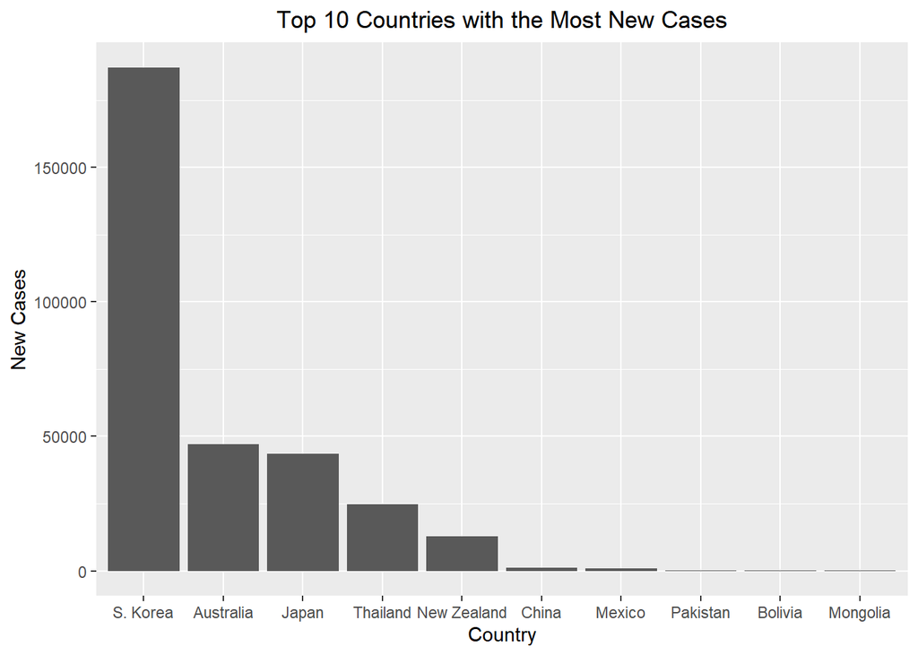

```r
top10NewCases %>%
  ggplot(aes(reorder(Country, -NewCases), NewCases)) +
  geom_bar(stat = "identity") +
  scale_y_continuous(labels = function(x) format(x, scientific = F)) +
  labs(
    x = "Country",
    y = "New Cases",
    title = "Top 10 Countries with the Most New Cases") +
  theme(plot.title = element_text(hjust = 0.5))
```

# Problem 2

## 1. Obtain your free API for https://spoonacular.com/food-api

```r
api_key <- "40d925facf66429f9d837537060df81d"
print(paste("API Key: ", api_key, sep = ""))
```

```
## [1] "API Key: 40d925facf66429f9d837537060df81d"
```

### Make API Request

```r
api_url <- paste(
  "https://api.spoonacular.com/recipes/complexSearch",
  "?apiKey=", api_key,
  sep = ""
)

url <- paste(
  api_url,
  "&cuisine=", "italian",
  "&includeNutrition=", "true",
  "&maxCarbs=", "30",
  "&sort=", "carbs",
  "&sortDirection=", "asc",
  sep = ""
)

# using api request to get json data
json_result <- url %>%
  curl() %>%
  readLines(warn=F)
```

### Convert to 10x3 tibble

```r
# convert json data to 10x3 tibble
result_t <- json_result %>%
  fromJSON() %>%
  .[[1]] %>%
  as_tibble() %>%
  mutate(
    Recipe = title,
    ID = id,
    Carbs = bind_rows(.$nutrition$nutrients)$amount) %>%
  select(Recipe, ID, Carbs)
result_t
```

```
## # A tibble: 10 x 3
##    Recipe                                                ID Carbs
##    <chr>                                              <int> <dbl>
##  1 Tiramisu Overnight Oats                          1697783  1.80
##  2 Mini eggplant pizza                               651956  2.11
##  3 Baked Ziti with Ricotta and Italian Sausage      1697599  2.78
##  4 Cast Iron Shrimp Pizza with Pecan Basil Pesto    1697557  2.81
##  5 Italian Caprese Sliders                           648084  2.90
##  6 Easy Shrimp Scampi                                642096  3.00
##  7 Just Another Tiramisu                             648660  3.30
##  8 Vegan Pea and Mint Pesto Bruschetta               664470  4.75
##  9 Shrimp Fettuccine Alfredo, Mamma Mia that's good 1697675  5.22
## 10 Easy Italian Meatballs                           1504227  5.23
```

## 3. Find 10 types of Riesling wines whose price do not exceed $50 and present your results as a 10x3 tibble, where the columns represent the title of the wine, its ID and its price.

### API Request

```r
api_url <- paste(
  "https://api.spoonacular.com/food/wine/recommendation",
  "?apiKey=", api_key,
  sep=""
)
url <- paste(
  api_url,
  "&wine=", "riesling",
  '&maxPrice=', "50",
  "&number=", "10",
  sep = ""
)

# using api request to get json data
json_result <- url %>%
  curl() %>%
  readLines(warn=F)
```

### Convert to 10x3 tibble

```r
# convert json data to 10x3 tibble
result_t <- json_result %>%
  fromJSON() %>%
  .[[1]] %>%
  as_tibble() %>%
  mutate(
    Title = title,
    ID = id,
    Price = price
  ) %>%
  select(Title, ID, Price) %>%
  mutate(Price = as.double(str_replace_all(.$Price, "[$]", "")))

result_t
```

```
## # A tibble: 10 x 3
##    Title                                                                ID Price
##    <chr>                                                             <int> <dbl>
##  1 Domaine LeSeurre Dry Cuvee Classique Riesling                    4.80e5 23.0
##  2 Chateau Ste. Michelle Riesling                                   4.77e5  9.99
##  3 J.J. Prum Graacher Himmelreich Kabinett Riesling                 4.38e5 22.0
##  4 Maximin Grunhaus Herrenberg Riesling Spatlese                    2.05e6 40.0
##  5 Weingut Darting Durkheimer Nonnengarten Riesling Kabinett (1 Li~ 2.04e6 18.0
##  6 Weingut Schneider Niederhauser Hermannshohle Riesling Trocken    5.00e5 30.0
##  7 Gunderloch Estate Riesling Dry                                   4.48e5 15.0
##  8 Forge Cellars Classique Riesling                                 4.60e5 21.0
##  9 Funf Riesling                                                    4.93e5  8.99
## 10 Selbach Oster Zeltinger Himmelreich Riesling Kabinett Halbtrock~ 2.04e6 21.0
```